# Pathology foundation-model research-software demonstration

29 September 2026

INTERNALLY DERIVED TCGA ESTIMATES

# COAD · TCGA-AA-A01F

TITAN representation; research-software output from supported cancer-specific models in PathoFMPred.

**UNVALIDATED RESEARCH OUTPUT****Reference rank, not probability**No independent external validationNot for diagnosis, treatment selection, or clinical risk estimation

Models applied**23**

Continuous**15**

Binary**8**

Slides pooled**1**

This research-software demonstration applies models developed and evaluated only in TCGA. Every displayed value is an **internally derived TCGA estimate**, not external performance evidence or a diagnostic output. Binary LDA scores are uncalibrated. Every displayed **Reference rank, not probability** describes relative position only.

For every cancer and representation, PathoFMPred displays only models that met the recorded representation-specific predictability rule. In the matched three-representation atlas, this means Q2 at least 0.20 for a continuous endpoint or AUROC at least 0.60 for a binary endpoint. TITAN tasks outside the common cohort must pass the supporting permutation/FDR screen. By default, the report also excludes continuous models developed with fewer than 100 labelled participants and binary models with fewer than 50 participants in either class. Explicit opt-in can add only these limited-sample threshold-crossing models. Tested-below-threshold reference objects never enter prediction reports.

## Prominent TCGA tissue-source-site-code sensitivity warning

**13 model(s) in this output fell below their original documented screening threshold under internal validation grouped by TCGA tissue-source-site code. These calls must not be highlighted without this warning.** The barcode-derived code is not an institution, scanner or laboratory identifier, and this grouping is not external validation.

| Endpoint (type) | TSS-grouped metric | Grouped minus random | Warning category |
| --- | --- | --- | --- |
| APC (binary) | BA 0.519 | -0.258 | Near chance or worse |
| MYC (binary) | BA 0.531 | -0.084 | Near chance or worse |
| MANTIS score (continuous) | Q2 0.107 | -0.177 | Below documented screening threshold |
| MSIsensor score (continuous) | Q2 0.094 | -0.127 | Below documented screening threshold |
| HALLMARK_ALLOGRAFT_REJECTION (continuous) | Q2 0.069 | -0.163 | Below documented screening threshold |
| HALLMARK_IL6_JAK_STAT3_SIGNALING (continuous) | Q2 0.134 | -0.072 | Below documented screening threshold |
| HALLMARK_INTERFERON_ALPHA_RESPONSE (continuous) | Q2 0.058 | -0.156 | Below documented screening threshold |
| HALLMARK_INTERFERON_GAMMA_RESPONSE (continuous) | Q2 0.177 | -0.074 | Below documented screening threshold |
| HALLMARK_MYOGENESIS (continuous) | Q2 0.152 | -0.068 | Below documented screening threshold |
| Macrophage Regulation (continuous) | Q2 -0.025 | -0.251 | Near chance or worse |
| Nonsilent Mutation Rate (continuous) | Q2 -0.006 | -0.281 | Near chance or worse |
| SNV Neoantigens (continuous) | Q2 0.015 | -0.226 | Below documented screening threshold |
| Silent Mutation Rate (continuous) | Q2 -0.004 | -0.263 | Near chance or worse |

## Case context (not used as model input)

**Shared selection features.** Both cases were men with sigmoid-colon, moderately differentiated (G2), pT3 adenocarcinoma and tumour-free resection margins. Nodal status was not matched: example A was pN1, whereas the available slide summary for example B did not state a nodal category.

**Pathology summary.** The sigmoid resection contained an ulcerated grade-2 adenocarcinoma that had crossed the muscular wall into pericolic fat (pT3). Both resection ends were free of carcinoma; lymphatic invasion was recorded, and 2 of 30 regional nodes contained metastasis (pN1).

**Clinical-context source.** Pathology was paraphrased from TCGA-Slide-Reports.csv distributed with the TITAN study (Ding et al., Nature Medicine 2025; doi:10.1038/s41591-025-03982-3).

The pathology field is descriptive context only; it was not a predictor, training target, or validation outcome for PathoFMPred.

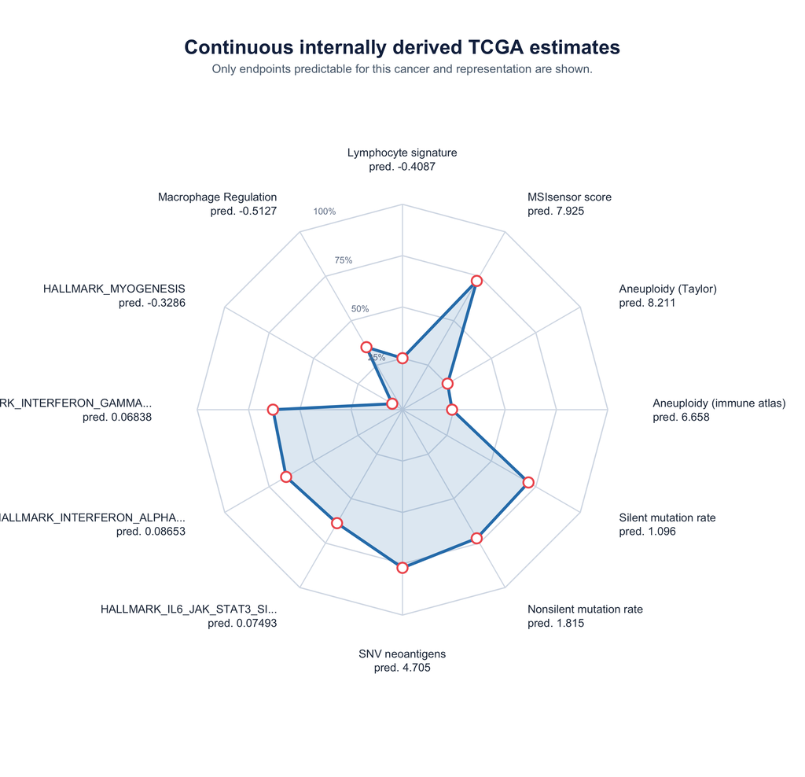

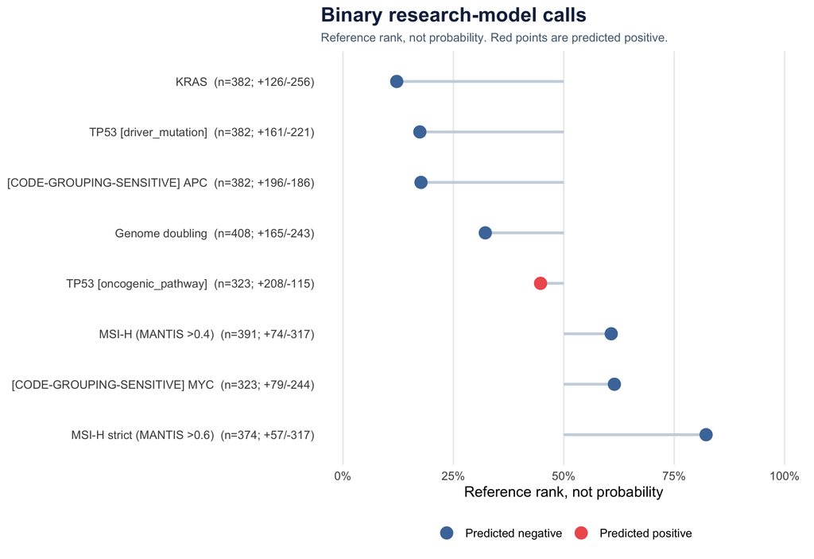

## Continuous internally derived estimates

| Family | Endpoint | Prediction | TCGA OOF rank (not probability) |
| --- | --- | --- | --- |
| rna_pathway_activity | HALLMARK_MYOGENESIS | -0.3286 | 5.8% |
| thorsson | SNV Neoantigens | 4.705 | 77.0% |
| thorsson | Aneuploidy Score | 6.658 | 24.1% |
| thorsson | Lymphocyte Infiltration Signature Score | -0.4087 | 25.1% |
| aneuploidy | Aneuploidy score | 8.211 | 25.4% |
| microsatellite_instability | MSIsensor score | 7.925 | 72.4% |
| thorsson | Nonsilent Mutation Rate | 1.815 | 72.3% |
| thorsson | Silent Mutation Rate | 1.096 | 70.9% |
| rna_pathway_activity | HALLMARK_INTERFERON_ALPHA_RESPONSE | 0.08653 | 65.4% |
| thorsson | Macrophage Regulation | -0.5127 | 35.1% |
| rna_pathway_activity | HALLMARK_IL6_JAK_STAT3_SIGNALING | 0.07493 | 63.8% |
| rna_pathway_activity | HALLMARK_INTERFERON_GAMMA_RESPONSE | 0.06838 | 63.1% |
| microsatellite_instability | MANTIS score | 0.4486 | 61.5% |
| thorsson | TIL Regional Fraction | 9.861 | 56.4% |
| rna_pathway_activity | HALLMARK_ALLOGRAFT_REJECTION | -0.02422 | 46.8% |

**Internal development evidence. The primary screen and five-repeat estimates use different nested-CV partitions and need not be identical.**

| Endpoint | Primary screen Q2 | Five-repeat Q2 | Five-repeat RMSE | Five-repeat Spearman |
| --- | --- | --- | --- | --- |
| Aneuploidy score | 0.302 | 0.276 | 6.963 | 0.563 |
| MANTIS score | 0.284 | 0.229 | 0.203 | 0.401 |
| MSIsensor score | 0.222 | 0.247 | 9.529 | 0.269 |
| HALLMARK_ALLOGRAFT_REJECTION | 0.233 | 0.225 | 0.416 | 0.478 |
| HALLMARK_IL6_JAK_STAT3_SIGNALING | 0.206 | 0.181 | 0.399 | 0.447 |
| HALLMARK_INTERFERON_ALPHA_RESPONSE | 0.215 | 0.199 | 0.485 | 0.448 |
| HALLMARK_INTERFERON_GAMMA_RESPONSE | 0.251 | 0.239 | 0.442 | 0.499 |
| HALLMARK_MYOGENESIS | 0.220 | 0.187 | 0.336 | 0.415 |
| Aneuploidy Score | 0.217 | 0.266 | 5.959 | 0.556 |
| Lymphocyte Infiltration Signature Score | 0.297 | 0.299 | 0.719 | 0.547 |
| Macrophage Regulation | 0.226 | 0.196 | 0.567 | 0.446 |
| Nonsilent Mutation Rate | 0.275 | 0.207 | 0.826 | 0.309 |
| SNV Neoantigens | 0.241 | 0.215 | 0.964 | 0.353 |
| Silent Mutation Rate | 0.259 | 0.244 | 0.650 | 0.336 |
| TIL Regional Fraction | 0.407 | 0.404 | 6.533 | 0.689 |

## Binary research-model calls

**Calls and development denominators.**

| Endpoint | Class | LDA score | Threshold | Rank, not probability | Training n (+/-) |
| --- | --- | --- | --- | --- | --- |
| Genome doubling | 0 | -2.153 | NA | 32.2% | 408 (+165/-243) |
| APC | 0 | -2.982 | NA | 17.7% | 382 (+196/-186) |
| KRAS | 0 | -5.333 | NA | 12.2% | 382 (+126/-256) |
| TP53 [driver_mutation] | 0 | -3.171 | NA | 17.4% | 382 (+161/-221) |
| MSI-H (MANTIS >0.4) | 0 | -3.146 | NA | 60.7% | 391 (+74/-317) |
| MSI-H strict (MANTIS >0.6) | 0 | -2.097 | NA | 82.2% | 374 (+57/-317) |
| MYC | 0 | -1.27 | NA | 61.5% | 323 (+79/-244) |
| TP53 [oncogenic_pathway] | 1 | 0.8362 | NA | 44.7% | 323 (+208/-115) |

**Internal development evidence. Primary AUROC and PR-AUC use nested held-out scores. The no-skill PR-AUC reference equals prevalence. Operating metrics and predictive values use training-derived thresholds.**

| Endpoint | AUROC | PR-AUC | Prevalence | No-skill PR-AUC | Threshold BA |
| --- | --- | --- | --- | --- | --- |
| Genome doubling | 0.727 | 0.644 | 0.404 | 0.404 | 0.665 |
| APC | 0.834 | 0.822 | 0.513 | 0.513 | 0.777 |
| KRAS | 0.751 | 0.559 | 0.330 | 0.330 | 0.676 |
| TP53 [driver_mutation] | 0.822 | 0.789 | 0.421 | 0.421 | 0.767 |
| MSI-H (MANTIS >0.4) | 0.836 | 0.626 | 0.189 | 0.189 | 0.732 |
| MSI-H strict (MANTIS >0.6) | 0.877 | 0.714 | 0.152 | 0.152 | 0.783 |
| MYC | 0.662 | 0.375 | 0.245 | 0.245 | 0.616 |
| TP53 [oncogenic_pathway] | 0.735 | 0.815 | 0.644 | 0.644 | 0.693 |

**Cohort-specific predictive values.**

| Endpoint | PPV | NPV | Sample-size stratum |
| --- | --- | --- | --- |
| Genome doubling | 0.623 | 0.749 | Larger-sample stratum |
| APC | 0.759 | 0.851 | Larger-sample stratum |
| KRAS | 0.580 | 0.785 | Larger-sample stratum |
| TP53 [driver_mutation] | 0.710 | 0.824 | Larger-sample stratum |
| MSI-H (MANTIS >0.4) | 0.662 | 0.894 | Larger-sample stratum |
| MSI-H strict (MANTIS >0.6) | 0.710 | 0.929 | Larger-sample stratum |
| MYC | 0.451 | 0.794 | Larger-sample stratum |
| TP53 [oncogenic_pathway] | 0.755 | 0.638 | Larger-sample stratum |

## Binary development reliability

**Fold class counts and component selection.**

| Endpoint | Minimum outer test (+/-) | Minimum inner training (+/-) | Components: median (range) |
| --- | --- | --- | --- |
| Genome doubling | +33 / -48 | +105 / -155 | 8.0 (2-16) |
| APC | +39 / -37 | +124 / -118 | 2.0 (1-5) |
| KRAS | +25 / -51 | +80 / -163 | 4.0 (2-20) |
| TP53 [driver_mutation] | +32 / -44 | +102 / -140 | 2.0 (2-7) |
| MSI-H (MANTIS >0.4) | +14 / -63 | +47 / -202 | 6.0 (4-13) |
| MSI-H strict (MANTIS >0.6) | +11 / -63 | +36 / -202 | 8.0 (5-16) |
| MYC | +15 / -48 | +50 / -156 | 4.0 (3-8) |
| TP53 [oncogenic_pathway] | +41 / -23 | +132 / -73 | 3.0 (1-7) |

**Repeat-to-repeat held-out prediction stability.**

| Endpoint | Score Spearman rho | Class agreement |
| --- | --- | --- |
| Genome doubling | 0.760 | 0.829 |
| APC | 0.943 | 0.942 |
| KRAS | 0.732 | 0.837 |
| TP53 [driver_mutation] | 0.929 | 0.923 |
| MSI-H (MANTIS >0.4) | 0.801 | 0.919 |
| MSI-H strict (MANTIS >0.6) | 0.759 | 0.945 |
| MYC | 0.821 | 0.892 |
| TP53 [oncogenic_pathway] | 0.862 | 0.900 |

## Quality and provenance

- Patient-level aggregation: arithmetic mean across all supplied slide vectors.
- Maximum fraction outside endpoint-specific TCGA training ranges: 0.3%.
- Foundation-model input schema: model-specific named features validated against the fitted artifact.
- Decomposition: seeded rSVD in fastPLS; binary classification: PLS-LDA.
- TCGA tissue-source-site-code metadata: every row includes the grouped internal metric, random-minus-grouped change, analysed-code count, threshold-retention status, fold-size range and inner-code-separation audit.
- Binary reliability metadata: held-out average precision, cohort-specific PPV/NPV, outer and inner class-count minima, selected-component distribution and repeat-to-repeat prediction stability.
- Default model selection: binary models require at least 50 TCGA participants in each class; smaller-class models are available only by explicit opt-in.
- Scope: internal validation grouped by TCGA tissue-source-site code is not institutional or scanner-level external validation.
- Intended use: research-software demonstration only; TCGA benchmark without independent external validation.

## Endpoint interpretation and target sources

For continuous endpoints, the TCGA OOF prediction percentile (not probability) locates the prediction within repeated TCGA out-of-fold predictions and is not a clinical reference interval. For binary endpoints, every Reference rank, not probability value is the relative position of an uncalibrated LDA score. It is not confidence or a clinical-risk estimate. PR-AUC is non-interpolated average precision for positive class 1. PPV and NPV are held-out estimates at the observed endpoint prevalence in this TCGA analysis and will change when prevalence changes. Rows marked exploratory/limited evidence are excluded from default inference and require explicit opt-in.

- **Genome doubling.** Binary whole-genome-doubling call derived from the tumour copy-number profile. *Analysed scale:* PLS-LDA class and uncalibrated discriminant score *Model-target source:* Taylor et al., Cancer Cell 2018, Table S2; doi:10.1016/j.ccell.2018.03.007.
- **APC.** Binary prediction of a qualifying protein-altering PASS mutation in APC; the displayed LDA score is not a probability. *Analysed scale:* PLS-LDA class and uncalibrated discriminant score *Model-target source:* MC3 consensus calls: Ellrott et al., Cell Systems 2018, doi:10.1016/j.cels.2018.03.002; cancer-gene eligibility: Bailey et al., Cell 2018, doi:10.1016/j.cell.2018.02.060.
- **KRAS.** Binary prediction of a qualifying protein-altering PASS mutation in KRAS; the displayed LDA score is not a probability. *Analysed scale:* PLS-LDA class and uncalibrated discriminant score *Model-target source:* MC3 consensus calls: Ellrott et al., Cell Systems 2018, doi:10.1016/j.cels.2018.03.002; cancer-gene eligibility: Bailey et al., Cell 2018, doi:10.1016/j.cell.2018.02.060.
- **TP53 [driver_mutation].** Binary prediction of a qualifying protein-altering PASS mutation in TP53; the displayed LDA score is not a probability. *Analysed scale:* PLS-LDA class and uncalibrated discriminant score *Model-target source:* MC3 consensus calls: Ellrott et al., Cell Systems 2018, doi:10.1016/j.cels.2018.03.002; cancer-gene eligibility: Bailey et al., Cell 2018, doi:10.1016/j.cell.2018.02.060.
- **MSI-H (MANTIS >0.4).** Binary call indicating whether the source MANTIS score exceeds 0.4; the displayed LDA score is not a probability. *Analysed scale:* PLS-LDA class and uncalibrated discriminant score *Model-target source:* Bonneville et al., JCO Precision Oncology 2017; doi:10.1200/PO.17.00073.
- **MSI-H strict (MANTIS >0.6).** Sensitivity-analysis call: MANTIS >0.6 is positive, <0.4 is negative, and intermediate source values were excluded from training. *Analysed scale:* PLS-LDA class and uncalibrated discriminant score *Model-target source:* Threshold documentation distributed with the cBioPortal TCGA PanCancer Atlas clinical sample files.
- **MYC.** Binary prediction that the MYC oncogenic pathway carries at least one qualifying genomic alteration; the displayed LDA score is not a probability. *Analysed scale:* PLS-LDA class and uncalibrated discriminant score *Model-target source:* Sanchez-Vega et al., Cell 2018, Table S4; doi:10.1016/j.cell.2018.03.035.
- **TP53 [oncogenic_pathway].** Binary prediction that the TP53 oncogenic pathway carries at least one qualifying genomic alteration; the displayed LDA score is not a probability. *Analysed scale:* PLS-LDA class and uncalibrated discriminant score *Model-target source:* Sanchez-Vega et al., Cell 2018, Table S4; doi:10.1016/j.cell.2018.03.035.
- **Aneuploidy score.** Number of chromosome arms with arm-level copy-number gain or loss; larger values indicate greater chromosomal imbalance. *Analysed scale:* source endpoint units *Model-target source:* Taylor et al., Cancer Cell 2018, Table S2; doi:10.1016/j.ccell.2018.03.007.
- **MANTIS score.** Genome-wide microsatellite-instability score from the MANTIS algorithm; larger values indicate stronger MSI evidence. *Analysed scale:* source endpoint units *Model-target source:* Kautto et al., Oncotarget 2017; doi:10.18632/oncotarget.20432. TCGA values were obtained from cBioPortal PanCancer Atlas records.
- **MSIsensor score.** Microsatellite-instability score from MSIsensor; larger values indicate a larger fraction of unstable microsatellite loci. *Analysed scale:* source endpoint units *Model-target source:* Niu et al., Bioinformatics 2014; doi:10.1093/bioinformatics/btt755. TCGA values were obtained from cBioPortal PanCancer Atlas records.
- **HALLMARK_ALLOGRAFT_REJECTION.** Model output for the named endpoint. Interpret together with its family, analysed scale and source publication. *Analysed scale:* source endpoint units *Model-target source:* See the PathoFMPred model registry and the companion analysis source manifest.
- **HALLMARK_IL6_JAK_STAT3_SIGNALING.** Model output for the named endpoint. Interpret together with its family, analysed scale and source publication. *Analysed scale:* source endpoint units *Model-target source:* See the PathoFMPred model registry and the companion analysis source manifest.
- **HALLMARK_INTERFERON_ALPHA_RESPONSE.** Model output for the named endpoint. Interpret together with its family, analysed scale and source publication. *Analysed scale:* source endpoint units *Model-target source:* See the PathoFMPred model registry and the companion analysis source manifest.
- **HALLMARK_INTERFERON_GAMMA_RESPONSE.** Model output for the named endpoint. Interpret together with its family, analysed scale and source publication. *Analysed scale:* source endpoint units *Model-target source:* See the PathoFMPred model registry and the companion analysis source manifest.
- **HALLMARK_MYOGENESIS.** Model output for the named endpoint. Interpret together with its family, analysed scale and source publication. *Analysed scale:* source endpoint units *Model-target source:* See the PathoFMPred model registry and the companion analysis source manifest.
- **Aneuploidy Score.** Aneuploidy burden distributed with the TCGA immune landscape resource; larger values indicate more arm-level copy-number alterations. *Analysed scale:* source endpoint units *Model-target source:* Thorsson et al., Immunity 2018, PanImmune_MS; doi:10.1016/j.immuni.2018.03.023.
- **Lymphocyte Infiltration Signature Score.** Gene-expression signature summarising lymphocyte-associated transcriptional infiltration; it is not a direct cell count. *Analysed scale:* source endpoint units *Model-target source:* Thorsson et al., Immunity 2018, PanImmune_MS; doi:10.1016/j.immuni.2018.03.023.
- **Macrophage Regulation.** Model output for the named endpoint. Interpret together with its family, analysed scale and source publication. *Analysed scale:* source endpoint units *Model-target source:* See the PathoFMPred model registry and the companion analysis source manifest.
- **Nonsilent Mutation Rate.** Rate of coding mutations that alter the encoded protein. PathoFMPred reports the model output on the analysis log(1+x) scale. *Analysed scale:* log1p-transformed source endpoint units *Model-target source:* Thorsson et al., Immunity 2018, PanImmune_MS; doi:10.1016/j.immuni.2018.03.023.
- **SNV Neoantigens.** Predicted neoantigen burden arising from single-nucleotide variants. PathoFMPred reports the model output on the analysis log(1+x) scale. *Analysed scale:* log1p-transformed source endpoint units *Model-target source:* Thorsson et al., Immunity 2018, PanImmune_MS; doi:10.1016/j.immuni.2018.03.023.
- **Silent Mutation Rate.** Rate of coding mutations that do not change the encoded amino acid. PathoFMPred reports the model output on the analysis log(1+x) scale. *Analysed scale:* log1p-transformed source endpoint units *Model-target source:* Thorsson et al., Immunity 2018, PanImmune_MS; doi:10.1016/j.immuni.2018.03.023.
- **TIL Regional Fraction.** Estimated fraction of tumour image regions containing tumour-infiltrating lymphocytes in the TCGA immune landscape resource. *Analysed scale:* source endpoint units *Model-target source:* Thorsson et al., Immunity 2018, PanImmune_MS; doi:10.1016/j.immuni.2018.03.023.